# notebook_blog

## Machine Learning versus Statistical Models for Time Series Forecasting

Floyd Mayweather versus Muhammed Ali. The greatest of all time versus the immortal legend. Wouldn’t that be the best match-up imaginable? No. Believe it or not, but I have a better one for you: The all-rounder with unlimited potential versus the consistently performing classic. Machine learning versus statistical models! Which one is better in time series forecasting?

Forecasting researcher Spyros Makridakis has been organizing several time series forecasting competitions (know as the M Competitions) to gain insights on the performance of different models. In the first three versions of the competition (1982, 1993 and 2000), only statistical models were used. In the last version of the competition however (2018), there was a significant number of machine learning models submitted as well. This blog provides a case that shows how both types of models perform in different scenarios. Let’s see if we can get some valuable insights on the pros and cons of both types of models. The used models were built in Python, and the code is available [here](https://github.com/NoahJSchutte/MLvsStats/blob/master/notebook_extensive.ipynb) as a Jupyter notebook.

## The match

Before we dive into the comparison, let’s give our definition of statistical and machine learning models. We define a statistical model as a model that is interpretable based on its architecture and mathematical representation. Examples of these are exponential smoothing and autoregressive-moving-average (ARIMA) models. We define a machine learning model as a model that has a relatively complex architecture with a significant number of not easy interpretable parameters. Examples of these in time series forecasting are recurrent neural networks (RNN) including long short-term memory (LSTM) cells or feedforward neural networks based on dilated causal convolutional layers.

Based on these definitions the statistical model should be able to give us insights the machine learning model does not. Furthermore, due to the difference in number of parameters we expect the statistical model to require significant less training time compared to the machine learning model. At the same time this does make the machine learning model more flexible and hopefully this makes it able to learn certain patterns by itself.

To see how both methods perform relative to each other, we picked one model of each type and use it to predict in three different scenarios. We look at a set of performance indicators that we will assess in the different sections of this blog. The following indicators were taken into account: Accuracy, learnability, explainability, modeling time, training time and data utility. They will be discussed throughout the blog. The match will take place in the city of Chicago. The time series data used is a data set of hourly energy consumption recorded by ComEd, the largest electricity distributor in (northern) Illinois, USA. The data has a horizon of January 1st, 2011 till August 2nd, 2018. Below is a plot of the data.

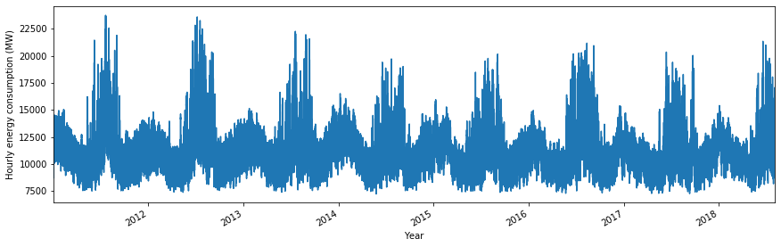

The goal will be to predict the next 24 hours of energy consumption. Accuracy will be measured by two error metrics. One is the symmetric mean average percentage error (sMAPE), which is chosen because it is easy to interpret. The other one is the mean absolute scaled error (MASE), which denotes the mean absolute error divided by the in-sample one-step naïve forecast and therefore shows the value of the predictive model relative to the naïve forecast.

## Round one: The competitors take the stage

In this round we will use February 2017 as our train data and the first week of March 2017 as test data. This means we will do 7 predictions of 24 hours, based on the data that is available at that point in time.

In one corner, we have the statistical model: a seasonal autoregressive-moving-average (SARIMA). This model is used since it gives us the possibility to model seasonality, while also providing the structure to model terms that deal with non-stationarity. Since there is a clear 24 hour per day season present, we use 24 as the periodicity of the season. To get the optimal order of the different model terms, we use a function (auto arima) that is built to do this. Besides that we also add the value of the week before as a term in our model, since there is also a weekday season present. After obtaining the right orders, we optimize the parameters and do our predictions. Below is a plot of the results.

```
The error metrics for these predictions are the following: 3.30% (sMAPE) and 0.55 (MASE)
```

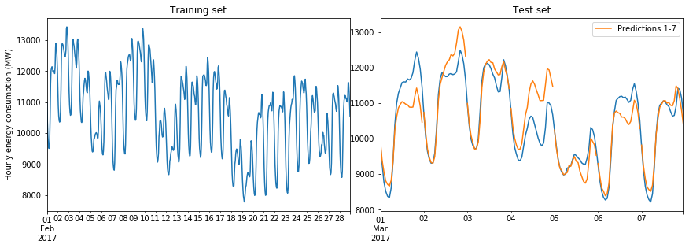

In the other corner we have our machine learning model: A neural network model based on LSTM cells. LSTM cells were created to be able to deal with time better than traditional recurrent neural network cells. Due to its structure, it ‘determines’ what time lags should be memorized, what lags should be forgotten and what lags should be used for the output when they go through the cell. We set up a layer of 48 LSTM cells followed by a regular feed forward neural network layer with 24 cells, which is the number we want as output. After this we train the model and get the results shown below.

```
The error metrics for these predictions are the following: 3.29% (sMAPE) and 0.53 (MASE)
```

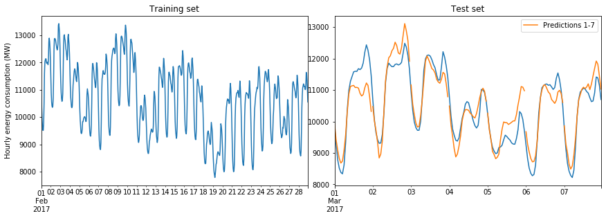

This LSTM model appears to be as accurate as the SARIMA model. It looks like it figured out both seasonal patterns without having any input specifying them. This shows that the machine learning model has better **learnability** than the statistical model. The statistical model learns how the different specified terms change the outcome by optimizing the model parameters, but due to its structure it will not learn anything outside of that scope. On the other hand, the machine learning model managed to determine important time lags without us giving it any direction.

## Round two: Going in with full force

Why only train on 4 weeks of data when we have such a big data set? There are no limitations on how hard a boxer is allowed to hit either. In this second round we do not limit the models and instead of training on 4 weeks of data, we use 4 years. Let’s start with the SARIMA model. Below are the obtained results.

```
The error metrics for these predictions are the following: 4.59% (sMAPE) and 0.57 (MASE)
```

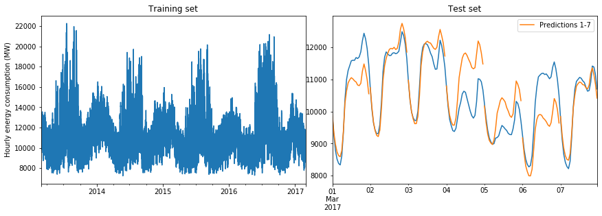

Maybe a bit surprising, but based on the sMAPE this model is significantly less accurate than the model we got when training on less data (1.29% difference). Since everything was kept the same except the increased training data, this can be the only reason why. Energy consumption clearly changes significantly throughout the year, but we are only predicting the first week of March. Therefore, it makes sense that just using data from February yields better results. Also, the similar value of the MASE (0.57 compared to 0.55) indicates that the model’s accuracy is similar compared to the naïve forecast of the training data. Therefore, we can conclude that the data has more variety throughout the year than in February. It is always important to realize what data you use for training and what you are trying to predict. More data is not always better! Let’s see what happens in the case of the LSTM model. Below are the results.

```
The error metrics for these predictions are the following: 2.36% (sMAPE) and 0.29 (MASE)
```

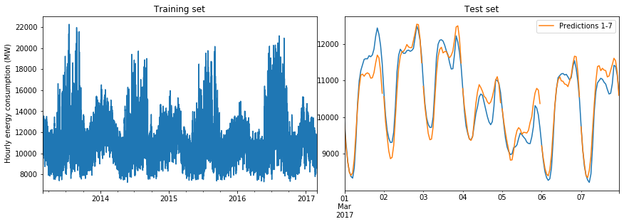

Contrary to the results we got from the SARIMA model, the LSTM model seems to be significantly more accurate when training on more data. This means that the reasoning presented for the worse accuracy of the statistical model does not seem to hold for the machine learning model. The model seems to have been able to use the extra data to better identify the occurring pattern instead of being thrown off by the changes of energy consumption throughout the year. This is why we can state that machine learning models tend to have a higher **data utility**, i.e. additional data has a more positive effect on the accuracy of the model.

## Round three: Coach gives critical advice

Even though it is the boxer that does the fighting, input from their coach is essential. Let's see if we can further improve our models if we give them some input from outside: An exogenous variable. We obtained a dataset with the hourly weather at the Chicago Midway International Airport. Even though this is not completely representative for the weather in the whole area from which the energy consumption is taken, we assume it is a decent proxy. We will use temperature since it is expected to have the highest causational effect on energy consumption. Below is a plot of the hourly temperature on top of the hourly energy consumption.

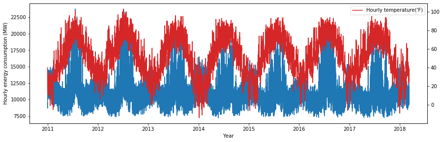

Based on this plot we can see that energy consumption goes up when the temperature is low, but also when the temperature is high. This is to be expected in Chicago, where high temperatures make cooling necessary and low temperatures require heating. We add the two lags with the highest correlation with energy consumption to our SARIMA model. This way we deviate a bit from time series analysis and turn the model partially in a regression model, but this combination hopefully allows the model to have better predictive power. We only use the data from February to train on since that gave us better results before. We make the (not completely accurate) assumption that temperature is known for the next 24 hours. Below are the results.

```
The error metrics for these predictions are the following: 2.94% (sMAPE) and 0.48 (MASE)
```

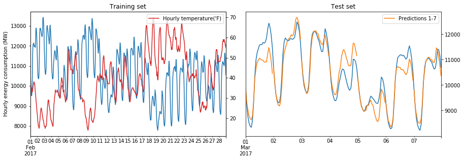

We see a clear improvement (0.36% sMAPE) in comparison with the earlier SARIMA model. But next to the improvement in accuracy, the structure of the SARIMA model gives us the ability to provide an answer to the question what the effect of temperature is on energy consumption. Predictive models are built on the premise that there is some relation between independent and dependent variables. Since statistics is a field of testing hypotheses around metrics that frequently relate to causality, statistical models are mostly easy to interpret and therefore yield great **explainability**. Let's look at the parameter coefficients below to see what we learn.

```
The SARIMA model parameter coefficients are as follows:
Y-168          0.905043
X-3           -6.826961
X-27           3.297200
ar.L1          0.954175
ar.L2          0.034851
ma.L1          0.372135
ma.L2          0.290757
ma.S.L24       0.355149
ma.S.L48       0.007161
sigma2      7025.931441
dtype: float64
```

Based on these parameters we can state a few things: The energy consumption of the next hour depends most heavily on the energy consumption of the week before (Y-168) and the energy consumption of the hour before (ar.L1), since both coefficients are above 0.90. A model error (difference between actual and predicted value) in one of the last two hours (ma.L1 and ma.L2) or 24 hours ago (ma.S.L24) will adjust the energy consumption of the predicted hour by about a third of its magnitude (all three coefficients between 0.29 and 0.38). For each degree Fahrenheit increase three hours before prediction (X-3), assuming everything else stays the same, the energy consumption will decrease by about 7 megawatt. This same increase for 27 hours before prediction (X-27) results in an increase of about 3 megawatt. The negative relationship makes sense since higher temperatures in February should lead to less heating. The positive relationship can be explained as being a counterbalance to the negative relationship. This combination of values indicates a negative relationship between energy consumption and temperature increase.

Let’s see how the LSTM model does. We adjust the model to have a second input and train it on 4 years of energy consumption and temperature data. Below are the results.

```
The error metrics for these predictions are the following: 1.28% (sMAPE) and 0.16 (MASE)
```

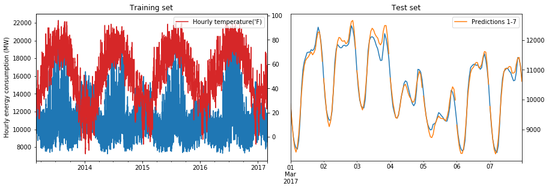

We see an even bigger improvement! A sMAPE of 1.28% makes this model really accurate. However, due to this model having 10,968 parameters, we are not able to get any explanation on the effect of temperature or different time lags on the results. Also, optimizing such a big number of parameters doesn’t happen overnight. It took more than 10 hours to train this LSTM model. With the SARIMA model having less than 10 parameters, it is clear why the **training time** is significantly lower. When a model requires frequent updates to keep accuracy high, it can be of great benefit to have a model that trains quick.

## Who is the winner?

No knockouts today, but I am sure you had as much excitement as I did watching this match! Who did you think should win? Looking at the match statistics, which are the performance indicators in our case, this is not so easy. Each indicator makes one model preferable over the other, so it depends on what you value most. Below is a graph with both models and the different indicators that make the model more preferable to the other. Hopefully this this can help as a guideline when deciding on a model type for a project.

[figure not shown]

Note that data utility ended up in the middle. Didn’t we see that the machine learning model got more accurate when using more data? It did, but that makes it a drawback to. Being able to get more value from data could also mean that the machine learning model is more dependent on data.

You probably noticed that there is one performance metric missing from the graph: **Accuracy**. Even though it has been clearly present throughout this analysis, we haven’t discussed it explicitly. Accuracy is often seen as the most important performance metric, since our main goal is to have accurate predictions. In this case the machine learning model outperformed the statistical model quite significantly. However, as said before, statistical models work better when more time is spent on optimizing the model. We did not take the time to fine tune the model, while we did allow the machine learning model to train as long as it needed to get (close to) its optimum. Also, one single case doesn't prove one model is more accurate than the other in general. Below is a summary of the error metrics in the different rounds.

[figure not shown]

In literature there has been an ongoing discussion on which type of models are more accurate. Due to statisticians relying on what has been the benchmark for years and computer scientists foreseeing endless capabilities with the recent rise of deep learning, it is not as easy to find an unbiased comparison. Comparisons are made frequently, but in the end the comparison for accuracy is only fair if both models are made by specialists in the field. So, what were the results of the last M competition I mentioned? The results showed that the most accurate models were the ones that combined a statistical with a machine learning model. The winning model was even more innovative, since it was a true hybrid in which the parameters of the statistical model and the machine learning model were fitted concurrently. This only strengthens our conclusion that both types of models have their benefits and their drawbacks. And if you are looking to make the perfect model, the best way to do that is probably using both!

**References**

Energy consumption data set: https://www.kaggle.com/robikscube/hourly-energy-consumption#pjm_hourly_est.csv  
Weather data set: https://www.ncdc.noaa.gov/cdo-web/datasets/LCD/stations/WBAN:14819/detail  
Makridakas Competitions: https://en.wikipedia.org/wiki/Makridakis_Competitions  
The M4 Competition: https://www.sciencedirect.com/science/article/pii/S0169207019301128